# Risk Factor Analysis

## Outcome Variable

**Outcome Variable:** wasted

## Predictor Variables

**Intervention Variable:** vagbrth

**Adjustment Set:**

unadjusted

## Stratifying Variables

The analysis was stratified on these variable(s):

- agecat
- studyid
- country

## Data Summary

| agecat | studyid | country | vagbrth | wasted | n_cell | n |
| --- | --- | --- | --- | --- | --- | --- |
| Birth | ki1000108-CMC-V-BCS-2002 | INDIA | 0 | 0 | 8 | 88 |
| Birth | ki1000108-CMC-V-BCS-2002 | INDIA | 0 | 1 | 2 | 88 |
| Birth | ki1000108-CMC-V-BCS-2002 | INDIA | 1 | 0 | 66 | 88 |
| Birth | ki1000108-CMC-V-BCS-2002 | INDIA | 1 | 1 | 12 | 88 |
| Birth | ki1000108-IRC | INDIA | 0 | 0 | 45 | 343 |
| Birth | ki1000108-IRC | INDIA | 0 | 1 | 21 | 343 |
| Birth | ki1000108-IRC | INDIA | 1 | 0 | 206 | 343 |
| Birth | ki1000108-IRC | INDIA | 1 | 1 | 71 | 343 |
| Birth | ki1017093c-NIH-Crypto | BANGLADESH | 0 | 0 | 0 | 17 |
| Birth | ki1017093c-NIH-Crypto | BANGLADESH | 0 | 1 | 1 | 17 |
| Birth | ki1017093c-NIH-Crypto | BANGLADESH | 1 | 0 | 15 | 17 |
| Birth | ki1017093c-NIH-Crypto | BANGLADESH | 1 | 1 | 1 | 17 |
| Birth | ki1119695-PROBIT | BELARUS | 0 | 0 | 1303 | 13824 |
| Birth | ki1119695-PROBIT | BELARUS | 0 | 1 | 290 | 13824 |
| Birth | ki1119695-PROBIT | BELARUS | 1 | 0 | 9633 | 13824 |
| Birth | ki1119695-PROBIT | BELARUS | 1 | 1 | 2598 | 13824 |
| Birth | ki1126311-ZVITAMBO | ZIMBABWE | 0 | 0 | 906 | 12813 |
| Birth | ki1126311-ZVITAMBO | ZIMBABWE | 0 | 1 | 193 | 12813 |
| Birth | ki1126311-ZVITAMBO | ZIMBABWE | 1 | 0 | 9861 | 12813 |
| Birth | ki1126311-ZVITAMBO | ZIMBABWE | 1 | 1 | 1853 | 12813 |
| Birth | kiGH5241-JiVitA-3 | BANGLADESH | 0 | 0 | 4 | 31378 |
| Birth | kiGH5241-JiVitA-3 | BANGLADESH | 0 | 1 | 0 | 31378 |
| Birth | kiGH5241-JiVitA-3 | BANGLADESH | 1 | 0 | 28366 | 31378 |
| Birth | kiGH5241-JiVitA-3 | BANGLADESH | 1 | 1 | 3008 | 31378 |
| Birth | kiGH5241-JiVitA-4 | BANGLADESH | 0 | 0 | 2 | 1366 |
| Birth | kiGH5241-JiVitA-4 | BANGLADESH | 0 | 1 | 0 | 1366 |
| Birth | kiGH5241-JiVitA-4 | BANGLADESH | 1 | 0 | 1292 | 1366 |
| Birth | kiGH5241-JiVitA-4 | BANGLADESH | 1 | 1 | 72 | 1366 |
| 6 months | ki1000108-CMC-V-BCS-2002 | INDIA | 0 | 0 | 21 | 368 |
| 6 months | ki1000108-CMC-V-BCS-2002 | INDIA | 0 | 1 | 4 | 368 |

[output cut: 70 more lines]

The following strata were considered:

- agecat: 24 months, studyid: ki1000108-CMC-V-BCS-2002, country: INDIA
- agecat: 24 months, studyid: ki1000108-IRC, country: INDIA
- agecat: 24 months, studyid: ki1017093b-PROVIDE, country: BANGLADESH
- agecat: 24 months, studyid: ki1017093c-NIH-Crypto, country: BANGLADESH
- agecat: 24 months, studyid: ki1066203-TanzaniaChild2, country: TANZANIA, UNITED REPUBLIC OF
- agecat: 24 months, studyid: ki1119695-PROBIT, country: BELARUS
- agecat: 24 months, studyid: ki1126311-ZVITAMBO, country: ZIMBABWE
- agecat: 24 months, studyid: kiGH5241-JiVitA-3, country: BANGLADESH
- agecat: 24 months, studyid: kiGH5241-JiVitA-4, country: BANGLADESH
- agecat: 6 months, studyid: ki1000108-CMC-V-BCS-2002, country: INDIA
- agecat: 6 months, studyid: ki1000108-IRC, country: INDIA
- agecat: 6 months, studyid: ki1017093b-PROVIDE, country: BANGLADESH
- agecat: 6 months, studyid: ki1017093c-NIH-Crypto, country: BANGLADESH
- agecat: 6 months, studyid: ki1066203-TanzaniaChild2, country: TANZANIA, UNITED REPUBLIC OF
- agecat: 6 months, studyid: ki1119695-PROBIT, country: BELARUS
- agecat: 6 months, studyid: ki1126311-ZVITAMBO, country: ZIMBABWE
- agecat: 6 months, studyid: kiGH5241-JiVitA-3, country: BANGLADESH
- agecat: 6 months, studyid: kiGH5241-JiVitA-4, country: BANGLADESH
- agecat: Birth, studyid: ki1000108-CMC-V-BCS-2002, country: INDIA
- agecat: Birth, studyid: ki1000108-IRC, country: INDIA
- agecat: Birth, studyid: ki1017093c-NIH-Crypto, country: BANGLADESH
- agecat: Birth, studyid: ki1119695-PROBIT, country: BELARUS
- agecat: Birth, studyid: ki1126311-ZVITAMBO, country: ZIMBABWE
- agecat: Birth, studyid: kiGH5241-JiVitA-3, country: BANGLADESH
- agecat: Birth, studyid: kiGH5241-JiVitA-4, country: BANGLADESH

### Dropped Strata

Some strata were dropped due to rare outcomes:

- agecat: Birth, studyid: ki1000108-CMC-V-BCS-2002, country: INDIA
- agecat: Birth, studyid: ki1017093c-NIH-Crypto, country: BANGLADESH
- agecat: Birth, studyid: kiGH5241-JiVitA-3, country: BANGLADESH
- agecat: Birth, studyid: kiGH5241-JiVitA-4, country: BANGLADESH
- agecat: 6 months, studyid: ki1000108-CMC-V-BCS-2002, country: INDIA
- agecat: 6 months, studyid: ki1017093c-NIH-Crypto, country: BANGLADESH
- agecat: 24 months, studyid: ki1000108-CMC-V-BCS-2002, country: INDIA
- agecat: 24 months, studyid: ki1066203-TanzaniaChild2, country: TANZANIA, UNITED REPUBLIC OF
- agecat: 24 months, studyid: ki1119695-PROBIT, country: BELARUS
- agecat: 24 months, studyid: ki1126311-ZVITAMBO, country: ZIMBABWE

## Methods Detail

We’re interested in the causal parameters $E[Y_a]$ for all values of $a \in \mathcal{A}$. These parameters represent the mean outcome if, possibly contrary to fact, we intervened to set all units to have $A=a$. Under the randomization and positivity assumptions, these are identified by the statistical parameters $\psi_a=E_W[E_{Y|A,W}(Y|A=a,W)]$. In addition, we’re interested in the mean of $Y$, $E[Y]$ under no intervention (the observed mean). We will estimate these parameters by using SuperLearner to fit the relevant likelihood factors – $E_{Y|A,W}(Y|A=a,W)$ and $p(A=a|W)$, and then updating our likelihood fit using a joint TMLE.

For unadjusted analyses ($W=\{\}$), initial likelihoods were estimated using Lrnr_glm to estimate the simple $E(Y|A)$ and Lrnr_mean to estimate $p(A)$. For adjusted analyses, a small library containing Lrnr_glmnet, Lrnr_xgboost, and Lrnr_mean was used.

Having estimated these parameters, we will then use the delta method to estimate relative risks and attributable risks relative to a prespecified baseline level of $A$.

# Results Detail

## Results Plots

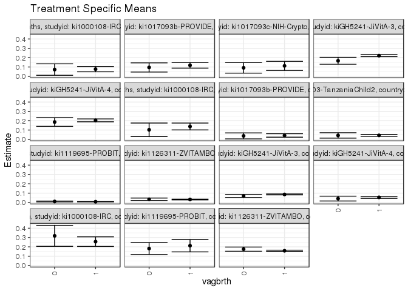

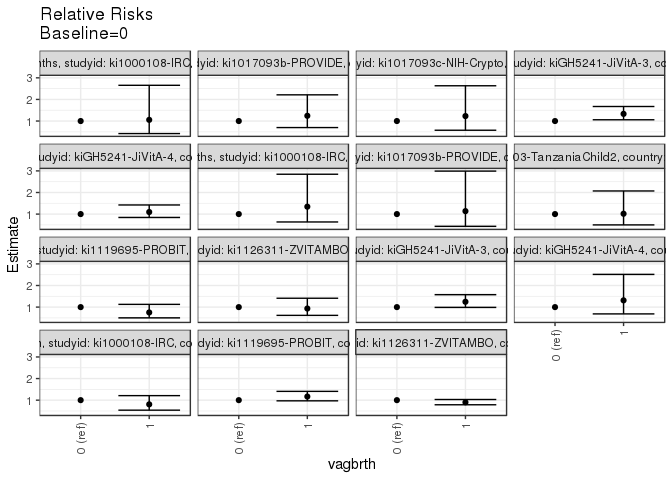

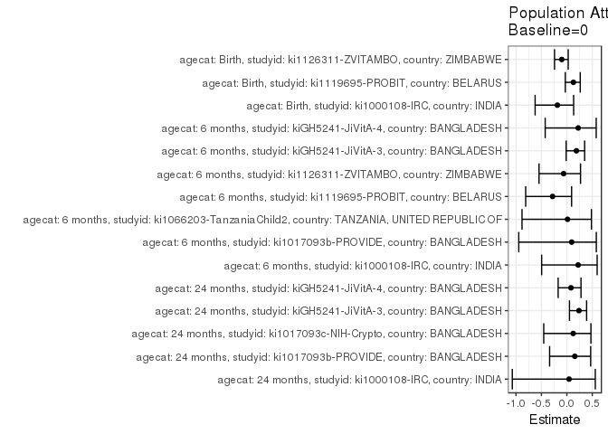

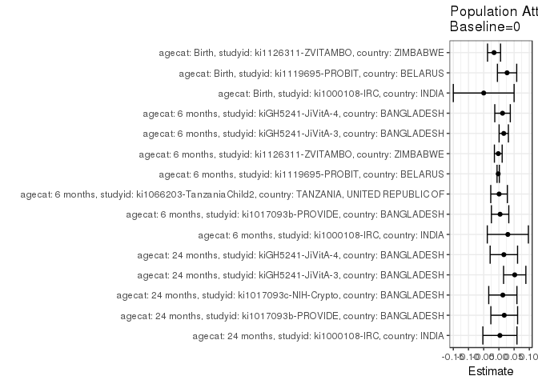

## Results Table

### Parameter: TSM

| agecat | studyid | country | intervention_level | baseline_level | estimate | ci_lower | ci_upper |
| --- | --- | --- | --- | --- | --- | --- | --- |
| Birth | ki1000108-IRC | INDIA | 0 | NA | 0.3181818 | 0.2056482 | 0.4307154 |
| Birth | ki1000108-IRC | INDIA | 1 | NA | 0.2563177 | 0.2048274 | 0.3078080 |
| Birth | ki1119695-PROBIT | BELARUS | 0 | NA | 0.1820465 | 0.1173892 | 0.2467037 |
| Birth | ki1119695-PROBIT | BELARUS | 1 | NA | 0.2124111 | 0.1459880 | 0.2788341 |
| Birth | ki1126311-ZVITAMBO | ZIMBABWE | 0 | NA | 0.1756142 | 0.1531179 | 0.1981105 |
| Birth | ki1126311-ZVITAMBO | ZIMBABWE | 1 | NA | 0.1581868 | 0.1515782 | 0.1647953 |
| 6 months | ki1000108-IRC | INDIA | 0 | NA | 0.1029412 | 0.0306257 | 0.1752567 |
| 6 months | ki1000108-IRC | INDIA | 1 | NA | 0.1382353 | 0.1015032 | 0.1749674 |
| 6 months | ki1017093b-PROVIDE | BANGLADESH | 0 | NA | 0.0373134 | 0.0051958 | 0.0694311 |
| 6 months | ki1017093b-PROVIDE | BANGLADESH | 1 | NA | 0.0424107 | 0.0237336 | 0.0610878 |
| 6 months | ki1066203-TanzaniaChild2 | TANZANIA, UNITED REPUBLIC OF | 0 | NA | 0.0423280 | 0.0136171 | 0.0710390 |
| 6 months | ki1066203-TanzaniaChild2 | TANZANIA, UNITED REPUBLIC OF | 1 | NA | 0.0429752 | 0.0336429 | 0.0523075 |
| 6 months | ki1119695-PROBIT | BELARUS | 0 | NA | 0.0105673 | 0.0059859 | 0.0151487 |
| 6 months | ki1119695-PROBIT | BELARUS | 1 | NA | 0.0079519 | 0.0063729 | 0.0095308 |
| 6 months | ki1126311-ZVITAMBO | ZIMBABWE | 0 | NA | 0.0339943 | 0.0206264 | 0.0473623 |
| 6 months | ki1126311-ZVITAMBO | ZIMBABWE | 1 | NA | 0.0317715 | 0.0277994 | 0.0357435 |
| 6 months | kiGH5241-JiVitA-3 | BANGLADESH | 0 | NA | 0.0688372 | 0.0528770 | 0.0847974 |
| 6 months | kiGH5241-JiVitA-3 | BANGLADESH | 1 | NA | 0.0858770 | 0.0809685 | 0.0907855 |
| 6 months | kiGH5241-JiVitA-4 | BANGLADESH | 0 | NA | 0.0416048 | 0.0157722 | 0.0674373 |
| 6 months | kiGH5241-JiVitA-4 | BANGLADESH | 1 | NA | 0.0546507 | 0.0443656 | 0.0649358 |
| 24 months | ki1000108-IRC | INDIA | 0 | NA | 0.0724638 | 0.0112173 | 0.1337102 |
| 24 months | ki1000108-IRC | INDIA | 1 | NA | 0.0764706 | 0.0481884 | 0.1047528 |
| 24 months | ki1017093b-PROVIDE | BANGLADESH | 0 | NA | 0.0948905 | 0.0457742 | 0.1440068 |
| 24 months | ki1017093b-PROVIDE | BANGLADESH | 1 | NA | 0.1179138 | 0.0877877 | 0.1480399 |
| 24 months | ki1017093c-NIH-Crypto | BANGLADESH | 0 | NA | 0.0909091 | 0.0341710 | 0.1476472 |
| 24 months | ki1017093c-NIH-Crypto | BANGLADESH | 1 | NA | 0.1118012 | 0.0630315 | 0.1605710 |
| 24 months | kiGH5241-JiVitA-3 | BANGLADESH | 0 | NA | 0.1663158 | 0.1293406 | 0.2032909 |
| 24 months | kiGH5241-JiVitA-3 | BANGLADESH | 1 | NA | 0.2214034 | 0.2110274 | 0.2317793 |
| 24 months | kiGH5241-JiVitA-4 | BANGLADESH | 0 | NA | 0.1860465 | 0.1396337 | 0.2324593 |
| 24 months | kiGH5241-JiVitA-4 | BANGLADESH | 1 | NA | 0.2037767 | 0.1884080 | 0.2191454 |

### Parameter: E(Y)

| agecat | studyid | country | intervention_level | baseline_level | estimate | ci_lower | ci_upper |
| --- | --- | --- | --- | --- | --- | --- | --- |
| Birth | ki1000108-IRC | INDIA | NA | NA | 0.2682216 | 0.2212677 | 0.3151755 |
| Birth | ki1119695-PROBIT | BELARUS | NA | NA | 0.2089120 | 0.1435514 | 0.2742726 |
| Birth | ki1126311-ZVITAMBO | ZIMBABWE | NA | NA | 0.1596816 | 0.1533387 | 0.1660245 |
| 6 months | ki1000108-IRC | INDIA | NA | NA | 0.1323529 | 0.0994307 | 0.1652752 |
| 6 months | ki1017093b-PROVIDE | BANGLADESH | NA | NA | 0.0412371 | 0.0250690 | 0.0574052 |
| 6 months | ki1066203-TanzaniaChild2 | TANZANIA, UNITED REPUBLIC OF | NA | NA | 0.0429142 | 0.0340389 | 0.0517895 |
| 6 months | ki1119695-PROBIT | BELARUS | NA | NA | 0.0082503 | 0.0066012 | 0.0098994 |
| 6 months | ki1126311-ZVITAMBO | ZIMBABWE | NA | NA | 0.0319629 | 0.0281547 | 0.0357711 |
| 6 months | kiGH5241-JiVitA-3 | BANGLADESH | NA | NA | 0.0847803 | 0.0799876 | 0.0895729 |
| 6 months | kiGH5241-JiVitA-4 | BANGLADESH | NA | NA | 0.0535670 | 0.0439013 | 0.0632327 |
| 24 months | ki1000108-IRC | INDIA | NA | NA | 0.0757946 | 0.0501131 | 0.1014762 |
| 24 months | ki1017093b-PROVIDE | BANGLADESH | NA | NA | 0.1124567 | 0.0866788 | 0.1382347 |
| 24 months | ki1017093c-NIH-Crypto | BANGLADESH | NA | NA | 0.1038462 | 0.0666939 | 0.1409984 |
| 24 months | kiGH5241-JiVitA-3 | BANGLADESH | NA | NA | 0.2183424 | 0.2084016 | 0.2282832 |
| 24 months | kiGH5241-JiVitA-4 | BANGLADESH | NA | NA | 0.2023482 | 0.1877608 | 0.2169356 |

### Parameter: RR

| agecat | studyid | country | intervention_level | baseline_level | estimate | ci_lower | ci_upper |
| --- | --- | --- | --- | --- | --- | --- | --- |
| Birth | ki1000108-IRC | INDIA | 0 | 0 | 1.0000000 | 1.0000000 | 1.000000 |
| Birth | ki1000108-IRC | INDIA | 1 | 0 | 0.8055699 | 0.5363593 | 1.209903 |
| Birth | ki1119695-PROBIT | BELARUS | 0 | 0 | 1.0000000 | 1.0000000 | 1.000000 |
| Birth | ki1119695-PROBIT | BELARUS | 1 | 0 | 1.1667961 | 0.9674617 | 1.407201 |
| Birth | ki1126311-ZVITAMBO | ZIMBABWE | 0 | 0 | 1.0000000 | 1.0000000 | 1.000000 |
| Birth | ki1126311-ZVITAMBO | ZIMBABWE | 1 | 0 | 0.9007631 | 0.7872150 | 1.030689 |
| 6 months | ki1000108-IRC | INDIA | 0 | 0 | 1.0000000 | 1.0000000 | 1.000000 |
| 6 months | ki1000108-IRC | INDIA | 1 | 0 | 1.3428571 | 0.6336429 | 2.845870 |
| 6 months | ki1017093b-PROVIDE | BANGLADESH | 0 | 0 | 1.0000000 | 1.0000000 | 1.000000 |
| 6 months | ki1017093b-PROVIDE | BANGLADESH | 1 | 0 | 1.1366071 | 0.4322192 | 2.988937 |
| 6 months | ki1066203-TanzaniaChild2 | TANZANIA, UNITED REPUBLIC OF | 0 | 0 | 1.0000000 | 1.0000000 | 1.000000 |
| 6 months | ki1066203-TanzaniaChild2 | TANZANIA, UNITED REPUBLIC OF | 1 | 0 | 1.0152893 | 0.4980591 | 2.069659 |
| 6 months | ki1119695-PROBIT | BELARUS | 0 | 0 | 1.0000000 | 1.0000000 | 1.000000 |
| 6 months | ki1119695-PROBIT | BELARUS | 1 | 0 | 0.7524970 | 0.5020383 | 1.127905 |
| 6 months | ki1126311-ZVITAMBO | ZIMBABWE | 0 | 0 | 1.0000000 | 1.0000000 | 1.000000 |
| 6 months | ki1126311-ZVITAMBO | ZIMBABWE | 1 | 0 | 0.9346104 | 0.6186218 | 1.412004 |
| 6 months | kiGH5241-JiVitA-3 | BANGLADESH | 0 | 0 | 1.0000000 | 1.0000000 | 1.000000 |
| 6 months | kiGH5241-JiVitA-3 | BANGLADESH | 1 | 0 | 1.2475376 | 0.9870740 | 1.576731 |
| 6 months | kiGH5241-JiVitA-4 | BANGLADESH | 0 | 0 | 1.0000000 | 1.0000000 | 1.000000 |
| 6 months | kiGH5241-JiVitA-4 | BANGLADESH | 1 | 0 | 1.3135683 | 0.6860140 | 2.515199 |
| 24 months | ki1000108-IRC | INDIA | 0 | 0 | 1.0000000 | 1.0000000 | 1.000000 |
| 24 months | ki1000108-IRC | INDIA | 1 | 0 | 1.0552941 | 0.4194722 | 2.654874 |
| 24 months | ki1017093b-PROVIDE | BANGLADESH | 0 | 0 | 1.0000000 | 1.0000000 | 1.000000 |
| 24 months | ki1017093b-PROVIDE | BANGLADESH | 1 | 0 | 1.2426303 | 0.6976751 | 2.213251 |
| 24 months | ki1017093c-NIH-Crypto | BANGLADESH | 0 | 0 | 1.0000000 | 1.0000000 | 1.000000 |
| 24 months | ki1017093c-NIH-Crypto | BANGLADESH | 1 | 0 | 1.2298137 | 0.5743075 | 2.633505 |
| 24 months | kiGH5241-JiVitA-3 | BANGLADESH | 0 | 0 | 1.0000000 | 1.0000000 | 1.000000 |
| 24 months | kiGH5241-JiVitA-3 | BANGLADESH | 1 | 0 | 1.3312227 | 1.0588262 | 1.673697 |
| 24 months | kiGH5241-JiVitA-4 | BANGLADESH | 0 | 0 | 1.0000000 | 1.0000000 | 1.000000 |
| 24 months | kiGH5241-JiVitA-4 | BANGLADESH | 1 | 0 | 1.0952996 | 0.8431890 | 1.422790 |

### Parameter: PAR

| agecat | studyid | country | intervention_level | baseline_level | estimate | ci_lower | ci_upper |
| --- | --- | --- | --- | --- | --- | --- | --- |
| Birth | ki1000108-IRC | INDIA | 0 | NA | -0.0499602 | -0.1499349 | 0.0500144 |
| Birth | ki1119695-PROBIT | BELARUS | 0 | NA | 0.0268656 | -0.0048531 | 0.0585843 |
| Birth | ki1126311-ZVITAMBO | ZIMBABWE | 0 | NA | -0.0159326 | -0.0373686 | 0.0055033 |
| 6 months | ki1000108-IRC | INDIA | 0 | NA | 0.0294118 | -0.0381917 | 0.0970152 |
| 6 months | ki1017093b-PROVIDE | BANGLADESH | 0 | NA | 0.0039237 | -0.0246761 | 0.0325234 |
| 6 months | ki1066203-TanzaniaChild2 | TANZANIA, UNITED REPUBLIC OF | 0 | NA | 0.0005861 | -0.0267563 | 0.0279285 |
| 6 months | ki1119695-PROBIT | BELARUS | 0 | NA | -0.0023170 | -0.0060910 | 0.0014570 |
| 6 months | ki1126311-ZVITAMBO | ZIMBABWE | 0 | NA | -0.0020314 | -0.0147759 | 0.0107131 |
| 6 months | kiGH5241-JiVitA-3 | BANGLADESH | 0 | NA | 0.0159431 | 0.0006975 | 0.0311886 |
| 6 months | kiGH5241-JiVitA-4 | BANGLADESH | 0 | NA | 0.0119623 | -0.0135656 | 0.0374901 |
| 24 months | ki1000108-IRC | INDIA | 0 | NA | 0.0033309 | -0.0527495 | 0.0594112 |
| 24 months | ki1017093b-PROVIDE | BANGLADESH | 0 | NA | 0.0175662 | -0.0264032 | 0.0615357 |
| 24 months | ki1017093c-NIH-Crypto | BANGLADESH | 0 | NA | 0.0129371 | -0.0334089 | 0.0592830 |
| 24 months | kiGH5241-JiVitA-3 | BANGLADESH | 0 | NA | 0.0520266 | 0.0153702 | 0.0886830 |
| 24 months | kiGH5241-JiVitA-4 | BANGLADESH | 0 | NA | 0.0163017 | -0.0287992 | 0.0614026 |

### Parameter: PAF

| agecat | studyid | country | intervention_level | baseline_level | estimate | ci_lower | ci_upper |
| --- | --- | --- | --- | --- | --- | --- | --- |
| Birth | ki1000108-IRC | INDIA | 0 | NA | -0.1862648 | -0.6239459 | 0.1334538 |
| Birth | ki1119695-PROBIT | BELARUS | 0 | NA | 0.1285976 | -0.0308338 | 0.2633709 |
| Birth | ki1126311-ZVITAMBO | ZIMBABWE | 0 | NA | -0.0997775 | -0.2425177 | 0.0265648 |
| 6 months | ki1000108-IRC | INDIA | 0 | NA | 0.2222222 | -0.4955071 | 0.5954962 |
| 6 months | ki1017093b-PROVIDE | BANGLADESH | 0 | NA | 0.0951493 | -0.9453954 | 0.5791319 |
| 6 months | ki1066203-TanzaniaChild2 | TANZANIA, UNITED REPUBLIC OF | 0 | NA | 0.0136582 | -0.8817567 | 0.4829989 |
| 6 months | ki1119695-PROBIT | BELARUS | 0 | NA | -0.2808377 | -0.8093682 | 0.0933050 |
| 6 months | ki1126311-ZVITAMBO | ZIMBABWE | 0 | NA | -0.0635556 | -0.5472123 | 0.2689106 |
| 6 months | kiGH5241-JiVitA-3 | BANGLADESH | 0 | NA | 0.1880515 | -0.0135718 | 0.3495672 |
| 6 months | kiGH5241-JiVitA-4 | BANGLADESH | 0 | NA | 0.2233139 | -0.4259645 | 0.5769591 |
| 24 months | ki1000108-IRC | INDIA | 0 | NA | 0.0439458 | -1.0726677 | 0.5590033 |
| 24 months | ki1017093b-PROVIDE | BANGLADESH | 0 | NA | 0.1562044 | -0.3390968 | 0.4683050 |
| 24 months | ki1017093c-NIH-Crypto | BANGLADESH | 0 | NA | 0.1245791 | -0.4545902 | 0.4731425 |
| 24 months | kiGH5241-JiVitA-3 | BANGLADESH | 0 | NA | 0.2382799 | 0.0514194 | 0.3883309 |
| 24 months | kiGH5241-JiVitA-4 | BANGLADESH | 0 | NA | 0.0805627 | -0.1712373 | 0.2782292 |